### Author: [Pratik Sharma](https://github.com/sharmapratik88/)

# Project 2 - Convolutional Neural Network - Dog Breed Identification App

### The Road Ahead

We break the notebook into separate steps. Feel free to use the links below to navigate the notebook.

- Import Datasets
- Detect Humans
- Detect Dogs
- CNN for Dog Breeds (Scratch)
- CNN for Dog Breeds (TL)
- Build Algorithm
- Test Algorithm

## Import Datasets

Downloading required human and dog datasets:

- Download the [dog dataset](https://s3-us-west-1.amazonaws.com/udacity-aind/dog-project/dogImages.zip). Unzip the folder and place it in this project's home directory, at the location `/dogImages`.
- Download the [human dataset](https://s3-us-west-1.amazonaws.com/udacity-aind/dog-project/lfw.zip). Unzip the folder and place it in the home directory, at location `/lfw`.

In the code cell below, we save the file paths for both the human (LFW) dataset and dog dataset in the numpy arrays `human_files` and `dog_files`.

```python
# Import packages
import matplotlib.pyplot as plt
from glob import glob
import numpy as np
import cvlib as cv
import cv2, torch
import os, random

# Torchvision
import torchvision.transforms as transforms
import torchvision.models as models
from torchvision import datasets

# Optimizers
from torch.optim.lr_scheduler import ReduceLROnPlateau
import torch.optim as optim

# Viewing the images
from PIL import Image, ImageFile
ImageFile.LOAD_TRUNCATED_IMAGES = True

%matplotlib inline

seed = 2020
np.random.seed(seed)
torch.manual_seed(seed)
torch.cuda.manual_seed_all(seed)

# Check if CUDA is available
use_cuda = torch.cuda.is_available()
if use_cuda: print('CUDA is available. Training on GPU ...')
```

```
CUDA is available. Training on GPU ...
```

```python
# Load filenames for human and dog images
human_files = np.array(glob('lfw/*/*'))
dog_files = np.array(glob('dogImages/*/*/*'))

# Print number of images in each dataset
print('There are %d total human images.' % len(human_files))
print('There are %d total dog images.' % len(dog_files))
```

```
There are 13233 total human images.
There are 8351 total dog images.
```

## Detect Humans

In this section, we use OpenCV's implementation of [Haar feature-based cascade classifiers](http://docs.opencv.org/trunk/d7/d8b/tutorial_py_face_detection.html) to detect human faces in images.

OpenCV provides many pre-trained face detectors, stored as XML files on [github](https://github.com/opencv/opencv/tree/master/data/haarcascades).

```
Number of faces detected: 3
```

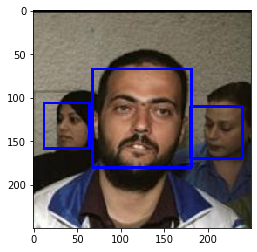

```python
# Extract pre-trained face detector
face_cascade = cv2.CascadeClassifier(cv2.data.haarcascades + 'haarcascade_frontalface_default.xml')

# Load color (BGR) image
img = cv2.imread(human_files[15])

# Convert BGR image to grayscale
gray = cv2.cvtColor(img, cv2.COLOR_BGR2GRAY)

# Find faces in image
faces = face_cascade.detectMultiScale(gray)

# Print number of faces detected in the image
print('Number of faces detected:', len(faces))

# Get bounding box for each detected face
for (x, y, w, h) in faces:
    cv2.rectangle(img, (x, y),(x+w, y+h), (255, 0, 0), 2)

# Convert BGR image to RGB for plotting
cv_rgb = cv2.cvtColor(img, cv2.COLOR_BGR2RGB)

# Display the image, along with bounding box
plt.imshow(cv_rgb)
plt.show()
```

Before using any of the face detectors, it is standard procedure to convert the images to grayscale. The `detectMultiScale` function executes the classifier stored in `face_cascade` and takes the grayscale image as a parameter.

In the above code, `faces` is a numpy array of detected faces, where each row corresponds to a detected face. Each detected face is a 1D array with four entries that specifies the bounding box of the detected face. The first two entries in the array (extracted in the above code as `x` and `y`) specify the horizontal and vertical positions of the top left corner of the bounding box. The last two entries in the array (extracted here as `w` and `h`) specify the width and height of the box.

### Write a Human Face Detector

We can use this procedure to write a function that returns `True` if a human face is detected in an image and `False` otherwise. This function, aptly named `face_detector`, takes a string-valued file path to an image as input and appears in the code block below.

```python
# Returns 'True' if face is detected in image stored at img_path
def face_detector(img_path):
    img = cv2.imread(img_path)
    gray = cv2.cvtColor(img, cv2.COLOR_BGR2GRAY)
    faces = face_cascade.detectMultiScale(gray)
    return len(faces) > 0
```

### (IMPLEMENTATION) Assess the Human Face Detector

**Question 1:** Use the code cell below to test the performance of the `face_detector` function.

- What percentage of the first 100 images in `human_files` have a detected human face?
- What percentage of the first 100 images in `dog_files` have a detected human face?

Ideally, we would like 100% of human images with a detected face and 0% of dog images with a detected face. You will see that our algorithm falls short of this goal, but still gives acceptable performance. We extract the file paths for the first 100 images from each of the datasets and store them in the numpy arrays `human_files_short` and `dog_files_short`.

**Answer:** 100 out of first 100 images in human files were detected as a human face by `face_detector` function. 41 out of first 100 images in dog files were detected as dog face by `face_detector` function.

```python
human_files_short = human_files[:100]
dog_files_short = dog_files[:100]

# Test the performance of the face_detector algorithm on the images in human_files_short and dog_files_short
print(f'Using Haar feature-based cascade classifiers, accuracy of `face_detector` in detecting human faces in first 100 images of human dataset: {sum([face_detector(img_path) for img_path in human_files_short])}%')
print(f'Using Haar feature-based cascade classifiers, accuracy of `face_detector` in detecting dog faces in first 100 images of dog dataset: {100 - sum([face_detector(img_path) for img_path in dog_files_short])}%')
```

```
Using Haar feature-based cascade classifiers, accuracy of `face_detector` in detecting human faces in first 100 images of human dataset: 100%
Using Haar feature-based cascade classifiers, accuracy of `face_detector` in detecting dog faces in first 100 images of dog dataset: 41%
```

```python
# Face detect using cvlib
def face_detect(img_path):
    im = cv2.imread(img_path)
    faces, confidences = cv.detect_face(im)
    return len(faces) > 0

print(f'Using cvlib, accuracy of `face_detect` in detecting human faces in first 100 images of human dataset: {sum([face_detect(img_path) for img_path in human_files_short])}%')
print(f'Using cvlib, accuracy of `face_detect` in detecting dog faces in first 100 images of dog dataset: {100 - sum([face_detect(img_path) for img_path in dog_files_short])}%')
```

```
Using cvlib, accuracy of `face_detect` in detecting human faces in first 100 images of human dataset: 100%
Using cvlib, accuracy of `face_detect` in detecting dog faces in first 100 images of dog dataset: 32%
```

## Detect Dogs

Use a [pre-trained model](http://pytorch.org/docs/master/torchvision/models.html) to detect dogs in images.

### Obtain Pre-trained VGG-16 Model

The code cell below downloads the VGG-16 model, along with weights that have been trained on [ImageNet](http://www.image-net.org/), a very large, very popular dataset used for image classification and other vision tasks. ImageNet contains over 10 million URLs, each linking to an image containing an object from one of [1000 categories](https://gist.github.com/yrevar/942d3a0ac09ec9e5eb3a).

```python
# Define VGG16 model
VGG16 = models.vgg16(pretrained = True)

# Move model to GPU if CUDA is available
if use_cuda:
    VGG16 = VGG16.cuda()
```

Given an image, this pre-trained VGG-16 model returns a prediction (derived from the 1000 possible categories in ImageNet) for the object that is contained in the image.

### (IMPLEMENTATION) Making Predictions with a Pre-trained Model

In the next code cell, writing a function that accepts a path to an image (such as `'dogImages/train/001.Affenpinscher/Affenpinscher_00001.jpg'`) as input and returns the index corresponding to the ImageNet class that is predicted by the pre-trained VGG-16 model. The output should always be an integer between 0 and 999, inclusive.

Before writing the function, here's the documentation to read about how to appropriately pre-process tensors for pre-trained models in the [PyTorch documentation](http://pytorch.org/docs/stable/torchvision/models.html).

```python
def VGG16_predict(img_path):
    '''
    Use pre-trained VGG-16 model to obtain index corresponding to
    predicted ImageNet class for image at specified path

    Args:
        img_path: path to an image

    Returns:
        Index corresponding to VGG-16 model's prediction
    '''

    # Load and pre-process an image from the given img_path
    # Return the *index* of the predicted class for that image

    image = Image.open(img_path)

    data_transform = transforms.Compose([transforms.Resize(255), transforms.CenterCrop(224), transforms.ToTensor(),
                                      transforms.Normalize([0.485, 0.456, 0.406], [0.229, 0.224, 0.225])])

    image = data_transform(image).float().unsqueeze(0)

    if use_cuda:
        image = image.cuda()
    VGG16.eval()
    output = VGG16(image)
    _, preds_tensor = torch.max(output, 1)
    preds = np.squeeze(preds_tensor.numpy()) if not use_cuda else np.squeeze(preds_tensor.cpu().numpy())

    return preds
```

```python
# Sample image
path = 'dogImages/train/001.Affenpinscher/Affenpinscher_00001.jpg'
idx = VGG16_predict(path)
print(f'Predicted index {idx} for image {path}.')
```

```
Predicted index 252 for image dogImages/train/001.Affenpinscher/Affenpinscher_00001.jpg.
```

### (IMPLEMENTATION) Write a Dog Detector

While looking at the [dictionary](https://gist.github.com/yrevar/942d3a0ac09ec9e5eb3a), you will notice that the categories corresponding to dogs appear in an uninterrupted sequence and correspond to dictionary keys 151-268, inclusive, to include all categories from `'Chihuahua'` to `'Mexican hairless'`. Thus, in order to check to see if an image is predicted to contain a dog by the pre-trained VGG-16 model, we need only check if the pre-trained model predicts an index between 151 and 268 (inclusive).

Use these ideas to complete the `dog_detector` function below, which returns `True` if a dog is detected in an image (and `False` if not).

```python
# Returns 'True' if a dog is detected in the image stored at img_path
def dog_detector(img_path):
    preds = VGG16_predict(img_path)
    return True if 151 <= preds <= 268 else False
```

### (IMPLEMENTATION) Assess the Dog Detector

**Question 2:** Use the code cell below to test the performance of your `dog_detector` function.

- What percentage of the images in `human_files_short` have a detected dog?
- What percentage of the images in `dog_files_short` have a detected dog?

**Answer:**

- Using **VGG16 model**, accuracy of `dog_detector` in detecting human faces in first 100 images of human dataset is 0% and the same is true for **ResNet-50 model**.
- Using **VGG16 model**, accuracy of `dog_detector` in detecting dog faces in first 100 images of dog dataset is 93% and an improvement of 2% with **ResNet-50 model**.

```python
# Test the performance of the dog_detector function on the images in human_files_short and dog_files_short
print(f'Using VGG16, accuracy of `dog_detector` in detecting human faces in first 100 images of human dataset: {sum([dog_detector(img_path) for img_path in human_files_short])}%')
print(f'Using VGG16, accuracy of `dog_detector` in detecting dog faces in first 100 images of dog dataset: {sum([dog_detector(img_path) for img_path in dog_files_short])}%')
```

```
Using VGG16, accuracy of `dog_detector` in detecting human faces in first 100 images of human dataset: 0%
Using VGG16, accuracy of `dog_detector` in detecting dog faces in first 100 images of dog dataset: 93%
```

We suggest VGG-16 as a potential network to detect dog images in your algorithm, but you are free to explore other pre-trained networks (such as [Inception-v3](http://pytorch.org/docs/master/torchvision/models.html#inception-v3), [ResNet-50](http://pytorch.org/docs/master/torchvision/models.html#id3), etc). Please use the code cell below to test other pre-trained PyTorch models. If you decide to pursue this *optional* task, report performance on `human_files_short` and `dog_files_short`.

```python
# Define ResNet-50 model
model = models.resnet50(pretrained = True)

use_cuda = torch.cuda.is_available()
if use_cuda: model = model.cuda()

# Modifying above function
def predict(img_path):
    image = Image.open(img_path)
    data_transform = transforms.Compose([transforms.Resize(255), transforms.CenterCrop(224), transforms.ToTensor(),
                                      transforms.Normalize([0.485, 0.456, 0.406], [0.229, 0.224, 0.225])])
    image = data_transform(image).float().unsqueeze(0)

    if use_cuda: image = image.cuda()
    model.eval()
    output = model(image)
    _, preds_tensor = torch.max(output, 1)
    preds = np.squeeze(preds_tensor.numpy()) if not use_cuda else np.squeeze(preds_tensor.cpu().numpy())
    return preds

def dog_detector(img_path):
    preds = predict(img_path)
    return True if 151 <= preds <= 268 else False

# Test the performance of the dog_detector function on the images in human_files_short and dog_files_short
print(f'Using ResNet-50, accuracy of `dog_detector` in detecting human faces in first 100 images of human dataset: {sum([dog_detector(img_path) for img_path in human_files_short])}%')
print(f'Using ResNet-50, accuracy of `dog_detector` in detecting dog faces in first 100 images of dog dataset: {sum([dog_detector(img_path) for img_path in dog_files_short])}%')
```

```
Using ResNet-50, accuracy of `dog_detector` in detecting human faces in first 100 images of human dataset: 0%
Using ResNet-50, accuracy of `dog_detector` in detecting dog faces in first 100 images of dog dataset: 95%
```

## Create a CNN to Classify Dog Breeds (from Scratch)

Now that we have functions for detecting humans and dogs in images, we need a way to predict breed from images. In this step, you will create a CNN that classifies dog breeds. You must create your CNN *from scratch* (so, you can't use transfer learning *yet*!), and you must attain a test accuracy of at least 10%. In Step 4 of this notebook, you will have the opportunity to use transfer learning to create a CNN that attains greatly improved accuracy.

We mention that the task of assigning breed to dogs from images is considered exceptionally challenging. To see why, consider that *even a human* would have trouble distinguishing between a Brittany and a Welsh Springer Spaniel.

[output not shown]

It is not difficult to find other dog breed pairs with minimal inter-class variation (for instance, Curly-Coated Retrievers and American Water Spaniels).

[output not shown]

Likewise, recall that labradors come in yellow, chocolate, and black. Your vision-based algorithm will have to conquer this high intra-class variation to determine how to classify all of these different shades as the same breed.

[output not shown]

We also mention that random chance presents an exceptionally low bar: setting aside the fact that the classes are slightly imabalanced, a random guess will provide a correct answer roughly 1 in 133 times, which corresponds to an accuracy of less than 1%.

Remember that the practice is far ahead of the theory in deep learning. Experiment with many different architectures, and trust your intuition. And, of course, have fun!

### (IMPLEMENTATION) Specify Data Loaders for the Dog Dataset

Use the code cell below to write three separate [data loaders](http://pytorch.org/docs/stable/data.html#torch.utils.data.DataLoader) for the training, validation, and test datasets of dog images (located at `dogImages/train`, `dogImages/valid`, and `dogImages/test`, respectively). You may find [this documentation on custom datasets](http://pytorch.org/docs/stable/torchvision/datasets.html) to be a useful resource. If you are interested in augmenting your training and/or validation data, check out the wide variety of [transforms](http://pytorch.org/docs/stable/torchvision/transforms.html?highlight=transform)!

```python
# Defining training and test data directories
data_dir = 'dogImages/'
train_dir = os.path.join(data_dir, 'train/')
valid_dir = os.path.join(data_dir, 'valid/')
test_dir = os.path.join(data_dir, 'test/')

# Defining transforms for the training, valid and test data
train_transforms = transforms.Compose([
    transforms.RandomResizedCrop(size = 256, scale = (0.8, 1.0)),
    transforms.RandomRotation(15),
    transforms.ColorJitter(brightness = 0.2, contrast = 0.2, saturation = 0.2, hue = 0.1),
    transforms.RandomHorizontalFlip(), transforms.RandomVerticalFlip(),
    transforms.CenterCrop(size = 224), transforms.ToTensor(),
    transforms.Normalize([0.485, 0.456, 0.406], [0.229, 0.224, 0.225])])

valid_transforms = transforms.Compose([
    transforms.Resize(256), transforms.CenterCrop(size = 224), transforms.ToTensor(),
    transforms.Normalize([0.485, 0.456, 0.406], [0.229, 0.224, 0.225])])

test_transforms = transforms.Compose([
    transforms.Resize(255), transforms.CenterCrop(224), transforms.ToTensor(),
    transforms.Normalize([0.485, 0.456, 0.406], [0.229, 0.224, 0.225])])

# Applying transforms
train_data = datasets.ImageFolder(train_dir, transform = train_transforms)
valid_data = datasets.ImageFolder(valid_dir, transform = train_transforms)
test_data = datasets.ImageFolder(test_dir, transform = test_transforms)
```

```python
# Set batch_size
batch_size = 32
# Set num_workers
num_workers = 0

# Loaders
trainloader = torch.utils.data.DataLoader(train_data, batch_size = batch_size, shuffle = True)
validloader = torch.utils.data.DataLoader(valid_data, batch_size = batch_size, shuffle = True)
testloader = torch.utils.data.DataLoader(test_data, batch_size = batch_size, shuffle = True)

loaders_scratch = {'train': trainloader, 'valid': validloader, 'test': testloader}

# Data stats
print(f'# of images in training set: {len(train_data)}')
print(f'# of images in valid set: {len(valid_data)}')
print(f'# of images in test set: {len(test_data)}')

# Class names
class_names = [classes[4:] for classes in sorted(train_data.classes)]
print(f'# of class: {len(class_names)}')
```

```
# of images in training set: 6680
# of images in valid set: 835
# of images in test set: 836
# of class: 133
```

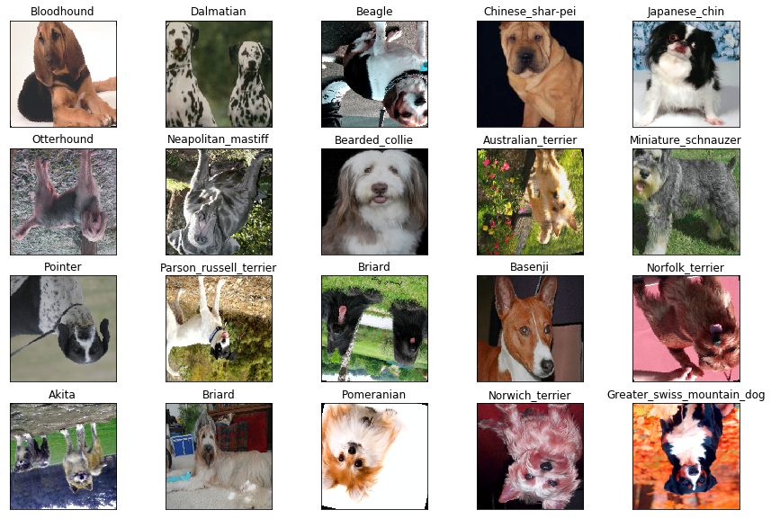

```python
# Helper function to un-normalize and display an image
def imshow(img):
    img = img.numpy().transpose((1, 2, 0))
    mean = np.array([0.485, 0.456, 0.406])
    stdev = np.array([0.229, 0.224, 0.225])
    img = stdev * img + mean
    img = np.clip(img, 0, 1)
    plt.imshow(img)

# Obtain one batch of training images
dataiter = iter(trainloader)
images, labels = dataiter.next()

# Plot the images in the batch, along with the corresponding labels
fig = plt.figure(figsize = (15, 10))

# Display 20 images
for idx in np.arange(20):
    ax = fig.add_subplot(4, 20/4, idx + 1, xticks = [], yticks = [])
    imshow(images[idx])
    ax.set_title(class_names[labels[idx]])
```

**Question 3:** Describe your chosen procedure for preprocessing the data.

- How does your code resize the images (by cropping, stretching, etc)? What size did you pick for the input tensor, and why?
- Did you decide to augment the dataset? If so, how (through translations, flips, rotations, etc)? If not, why not?

### (IMPLEMENTATION) Model Architecture

Create a CNN to classify dog breed. Use the template in the code cell below.

```python
import torch.nn as nn
import torch.nn.functional as F

# define the CNN architecture
class Net(nn.Module):
    def __init__(self, init_weights = True):
        super(Net, self).__init__()
        # Define layers of a CNN
        # Convolutional layer (sees 224x224x3 tensor)
        self.conv1 = nn.Conv2d(3, 16, 3, padding = 1)

        # Convolutional layer (sees 112x112x16 tensor)
        self.conv2 = nn.Conv2d(16, 32, 3, padding = 1)

        # Convolutional layer (sees 54x54x32 tensor)
        self.conv3 = nn.Conv2d(32, 64, 3, padding = 1)

        # Convolutional layer (sees 28x28x64 tensor)
        self.conv4 = nn.Conv2d(64, 128, 3, padding = 1)

        # Convolutional layer (sees 28x28x128 tensor)
        self.conv5 = nn.Conv2d(128, 256, 3, padding = 1)

        # Max pooling layer
        self.pool = nn.MaxPool2d(2, 2)

        # Average pooling layer
        self.poolavg = nn.AvgPool2d(14, 14)

        # Linear layer (256 -> 133)
        self.fc1 = nn.Linear(256, len(class_names))

        # Dropout layer
        self.dropout = nn.Dropout(0.2)

        # Batch normalization layers
        self.bn1 = nn.BatchNorm2d(16)
        self.bn2 = nn.BatchNorm2d(32)
        self.bn3 = nn.BatchNorm2d(64)
        self.bn4 = nn.BatchNorm2d(128)
        self.bn5 = nn.BatchNorm2d(256)

        if init_weights: self._initialize_weights()

    # Function for weight initialization
    def _initialize_weights(self):
        for m in self.modules():
            if isinstance(m, nn.Conv2d):
                nn.init.kaiming_normal_(m.weight, mode = 'fan_out', nonlinearity = 'relu')
                if m.bias is not None:
                    nn.init.constant_(m.bias, 0)
            elif isinstance(m, nn.BatchNorm2d):
                nn.init.constant_(m.weight, 1)
                nn.init.constant_(m.bias, 0)
            elif isinstance(m, nn.Linear):
                nn.init.normal_(m.weight, 0, 0.01)
                nn.init.constant_(m.bias, 0)

    def forward(self, x):
        # Define forward behavior
        x = self.pool(F.relu(self.bn1(self.conv1(x))))
        x = self.pool(F.relu(self.bn2(self.conv2(x))))
        x = self.pool(F.relu(self.bn3(self.conv3(x))))
        x = self.pool(F.relu(self.bn4(self.conv4(x))))
        x = self.poolavg(F.relu(self.bn5(self.conv5(x))))
        x = x.view(-1, 256)
        x = self.dropout(x)
        x = self.fc1(x)

        return x

# Instantiate the CNN
model_scratch = Net()
print(model_scratch)

# Move model to GPU, if available
if use_cuda:
    model_scratch.cuda()
```

```
Net(
  (conv1): Conv2d(3, 16, kernel_size=(3, 3), stride=(1, 1), padding=(1, 1))
  (conv2): Conv2d(16, 32, kernel_size=(3, 3), stride=(1, 1), padding=(1, 1))
  (conv3): Conv2d(32, 64, kernel_size=(3, 3), stride=(1, 1), padding=(1, 1))
  (conv4): Conv2d(64, 128, kernel_size=(3, 3), stride=(1, 1), padding=(1, 1))
  (conv5): Conv2d(128, 256, kernel_size=(3, 3), stride=(1, 1), padding=(1, 1))
  (pool): MaxPool2d(kernel_size=2, stride=2, padding=0, dilation=1, ceil_mode=False)
  (poolavg): AvgPool2d(kernel_size=14, stride=14, padding=0)
  (fc1): Linear(in_features=256, out_features=133, bias=True)
  (dropout): Dropout(p=0.2, inplace=False)
  (bn1): BatchNorm2d(16, eps=1e-05, momentum=0.1, affine=True, track_running_stats=True)
  (bn2): BatchNorm2d(32, eps=1e-05, momentum=0.1, affine=True, track_running_stats=True)
  (bn3): BatchNorm2d(64, eps=1e-05, momentum=0.1, affine=True, track_running_stats=True)
  (bn4): BatchNorm2d(128, eps=1e-05, momentum=0.1, affine=True, track_running_stats=True)
  (bn5): BatchNorm2d(256, eps=1e-05, momentum=0.1, affine=True, track_running_stats=True)
)
```

**Question 4:** Outline the steps you took to get to your final CNN architecture and your reasoning at each step.

### (IMPLEMENTATION) Specify Loss Function and Optimizer

Use the next code cell to specify a [loss function](http://pytorch.org/docs/stable/nn.html#loss-functions) and [optimizer](http://pytorch.org/docs/stable/optim.html). Save the chosen loss function as `criterion_scratch`, and the optimizer as `optimizer_scratch` below.

```python
# Select loss function (categorical cross-entropy)
criterion_scratch = nn.CrossEntropyLoss()

# Select optimizer
optimizer_scratch = optim.Adam(model_scratch.parameters(), lr = 0.001)

# Reduce learning rate when a metric has stopped improving
scheduler_lr = ReduceLROnPlateau(optimizer_scratch, mode = 'min', patience = 0, factor = 0.1, cooldown = 1, verbose = True)
```

### (IMPLEMENTATION) Train and Validate the Model

Train and validate your model in the code cell below. [Save the final model parameters](http://pytorch.org/docs/master/notes/serialization.html) at filepath `'model_scratch.pt'`.

```python
def train(n_epochs, loaders, model, optimizer, criterion, scheduler, use_cuda, reducer, save_path):
    """returns trained model"""
    # Initialize tracker for minimum validation loss
    valid_loss_min = np.Inf

    for epoch in range(1, n_epochs + 1):
        # Initialize variables to monitor training and validation loss
        train_loss = 0.0
        valid_loss = 0.0

        ###################
        # Train the model #
        ###################
        model.train()
        for batch_idx, (data, target) in enumerate(loaders['train']):
            # Move to GPU, if available
            if use_cuda:
                data, target = data.cuda(), target.cuda()

            # Clear the gradients of all optimized variables
            optimizer.zero_grad()

            # Forward pass: compute predicted outputs by passing inputs to the model
            output = model(data)

            # Calculate the batch loss
            loss = criterion(output, target)

            # Backward pass: compute gradient of the loss with respect to model parameters
            loss.backward()

            # Perform a single optimization step
            optimizer.step()

            # Update training loss
            train_loss += ((1 / (batch_idx + 1)) * (loss.data - train_loss))

        ######################
        # Validate the model #
        ######################
        model.eval()
        for batch_idx, (data, target) in enumerate(loaders['valid']):
            # Move to GPU, if available
            if use_cuda:
                data, target = data.cuda(), target.cuda()

            # Forward pass: compute predicted outputs by passing inputs to the model
            output = model(data)

            # Calculate the batch loss
            loss = criterion(output, target)

            # Update average validation loss
            valid_loss += ((1 / (batch_idx + 1)) * (loss.data - valid_loss))

        # Print training/validation statistics
        print('Epoch: {} \tTraining Loss: {:.6f} \tValidation Loss: {:.6f}'.format(epoch, train_loss, valid_loss))

        # Save model if validation loss has decreased
        if valid_loss <= valid_loss_min:
            print('Validation loss decreased ({:.6f} --> {:.6f}).  Saving model ...'.format(valid_loss_min, valid_loss))
            torch.save(model.state_dict(), save_path)
            valid_loss_min = valid_loss
        if epoch > reducer:
            # Perform a single lr scheduler step
            scheduler.step(valid_loss_min)

    # Return trained model
    return model

# Train the model
model_scratch = train(n_epochs = 40, loaders = loaders_scratch, model = model_scratch,
                      optimizer = optimizer_scratch, criterion = criterion_scratch,
                      scheduler = scheduler_lr, use_cuda = use_cuda, reducer = 20,
                      save_path = 'model_scratch.pt')

# Load the model that got the best validation accuracy
model_scratch.load_state_dict(torch.load('model_scratch.pt'))
```

```
Epoch: 1 	Training Loss: 4.740582 	Validation Loss: 4.616798
Validation loss decreased (inf --> 4.616798).  Saving model ...
Epoch: 2 	Training Loss: 4.458874 	Validation Loss: 4.392845
Validation loss decreased (4.616798 --> 4.392845).  Saving model ...
Epoch: 3 	Training Loss: 4.257885 	Validation Loss: 4.348064
Validation loss decreased (4.392845 --> 4.348064).  Saving model ...
Epoch: 4 	Training Loss: 4.075589 	Validation Loss: 4.170229
Validation loss decreased (4.348064 --> 4.170229).  Saving model ...
Epoch: 5 	Training Loss: 3.905663 	Validation Loss: 3.939425
Validation loss decreased (4.170229 --> 3.939425).  Saving model ...
Epoch: 6 	Training Loss: 3.768619 	Validation Loss: 4.109581
Epoch: 7 	Training Loss: 3.661864 	Validation Loss: 3.938936
Validation loss decreased (3.939425 --> 3.938936).  Saving model ...
Epoch: 8 	Training Loss: 3.591775 	Validation Loss: 3.954947
Epoch: 9 	Training Loss: 3.489053 	Validation Loss: 4.016362
Epoch: 10 	Training Loss: 3.411896 	Validation Loss: 3.746945
Validation loss decreased (3.938936 --> 3.746945).  Saving model ...
Epoch: 11 	Training Loss: 3.335089 	Validation Loss: 3.888906
Epoch: 12 	Training Loss: 3.282391 	Validation Loss: 3.531636
Validation loss decreased (3.746945 --> 3.531636).  Saving model ...
Epoch: 13 	Training Loss: 3.198157 	Validation Loss: 3.530979
Validation loss decreased (3.531636 --> 3.530979).  Saving model ...
Epoch: 14 	Training Loss: 3.153288 	Validation Loss: 3.323216
Validation loss decreased (3.530979 --> 3.323216).  Saving model ...
Epoch: 15 	Training Loss: 3.084947 	Validation Loss: 3.926060
Epoch: 16 	Training Loss: 3.044966 	Validation Loss: 3.279199
Validation loss decreased (3.323216 --> 3.279199).  Saving model ...
Epoch: 17 	Training Loss: 2.976663 	Validation Loss: 3.240146
Validation loss decreased (3.279199 --> 3.240146).  Saving model ...
Epoch: 18 	Training Loss: 2.892899 	Validation Loss: 3.357533
Epoch: 19 	Training Loss: 2.867773 	Validation Loss: 3.328386
Epoch: 20 	Training Loss: 2.809733 	Validation Loss: 3.219929
Validation loss decreased (3.240146 --> 3.219929).  Saving model ...
Epoch: 21 	Training Loss: 2.750171 	Validation Loss: 3.594382
Epoch: 22 	Training Loss: 2.721190 	Validation Loss: 3.217013
Validation loss decreased (3.219929 --> 3.217013).  Saving model ...
Epoch: 23 	Training Loss: 2.690023 	Validation Loss: 2.985996
Validation loss decreased (3.217013 --> 2.985996).  Saving model ...
Epoch: 24 	Training Loss: 2.640955 	Validation Loss: 3.017190
Epoch     4: reducing learning rate of group 0 to 1.0000e-04.
```

[output cut: 10 more lines]

```
Epoch    10: reducing learning rate of group 0 to 1.0000e-07.
Epoch: 31 	Training Loss: 2.322517 	Validation Loss: 2.650973
Epoch: 32 	Training Loss: 2.344588 	Validation Loss: 2.629614
Epoch    12: reducing learning rate of group 0 to 1.0000e-08.
Epoch: 33 	Training Loss: 2.348624 	Validation Loss: 2.597049
Validation loss decreased (2.609148 --> 2.597049).  Saving model ...
Epoch: 34 	Training Loss: 2.329235 	Validation Loss: 2.593755
Validation loss decreased (2.597049 --> 2.593755).  Saving model ...
Epoch: 35 	Training Loss: 2.336605 	Validation Loss: 2.611048
Epoch: 36 	Training Loss: 2.334644 	Validation Loss: 2.624000
Epoch: 37 	Training Loss: 2.333885 	Validation Loss: 2.663054
Epoch: 38 	Training Loss: 2.358796 	Validation Loss: 2.592891
Validation loss decreased (2.593755 --> 2.592891).  Saving model ...
Epoch: 39 	Training Loss: 2.333731 	Validation Loss: 2.594156
Epoch: 40 	Training Loss: 2.331869 	Validation Loss: 2.631305
```

```
<All keys matched successfully>
```

### (IMPLEMENTATION) Test the Model

Try out your model on the test dataset of dog images. Use the code cell below to calculate and print the test loss and accuracy. Ensure that your test accuracy is greater than 10%.

```python
def test(loaders, model, criterion, use_cuda):

    # Monitor test loss and accuracy
    test_loss = 0.
    correct = 0.
    total = 0.

    model.eval()
    for batch_idx, (data, target) in enumerate(loaders['test']):
        # Move to GPU, if available
        if use_cuda:
            data, target = data.cuda(), target.cuda()

        # Forward pass: compute predicted outputs by passing inputs to the model
        output = model(data)

        # Calculate the loss
        loss = criterion(output, target)

        # Update average test loss
        test_loss += ((1 / (batch_idx + 1)) * (loss.data - test_loss))

        # Convert output probabilities to predicted class
        pred = output.data.max(1, keepdim = True)[1]

        # Compare predictions to true label
        correct += np.sum(np.squeeze(pred.eq(target.data.view_as(pred))).cpu().numpy())
        total += data.size(0)

    print('Test Loss: {:.6f}\n'.format(test_loss))

    print('\nTest Accuracy: %2d%% (%2d/%2d)' % (100. * correct / total, correct, total))

# Call test function
test(loaders_scratch, model_scratch, criterion_scratch, use_cuda)
```

```
Test Loss: 2.511808


Test Accuracy: 35% (298/836)
```

## Create a CNN to Classify Dog Breeds (using Transfer Learning)

You will now use transfer learning to create a CNN that can identify dog breed from images. Your CNN must attain at least 60% accuracy on the test set.

I'll use the same data transformations to load the dataset, to easily compare the performance of two models.

```python
# Specify data loaders
loaders_transfer = loaders_scratch
```

### (IMPLEMENTATION) Model Architecture

Use transfer learning to create a CNN to classify dog breed. Use the code cell below, and save your initialized model as the variable `model_transfer`.

```python
# ResNet-50 model
model_transfer = models.resnet50(pretrained = True)

# Freezing all parameters
for param in model_transfer.parameters():
    param.requires_grad = False

# Replacing fully connected layer
in_ = model_transfer.fc.in_features
model_transfer.fc = nn.Linear(in_features = in_, out_features = len(class_names))

# Move to GPU, if available
if use_cuda:
    model_transfer = model_transfer.cuda()
print(model_transfer)
```

```
ResNet(
  (conv1): Conv2d(3, 64, kernel_size=(7, 7), stride=(2, 2), padding=(3, 3), bias=False)
  (bn1): BatchNorm2d(64, eps=1e-05, momentum=0.1, affine=True, track_running_stats=True)
  (relu): ReLU(inplace=True)
  (maxpool): MaxPool2d(kernel_size=3, stride=2, padding=1, dilation=1, ceil_mode=False)
  (layer1): Sequential(
    (0): Bottleneck(
      (conv1): Conv2d(64, 64, kernel_size=(1, 1), stride=(1, 1), bias=False)
      (bn1): BatchNorm2d(64, eps=1e-05, momentum=0.1, affine=True, track_running_stats=True)
      (conv2): Conv2d(64, 64, kernel_size=(3, 3), stride=(1, 1), padding=(1, 1), bias=False)
      (bn2): BatchNorm2d(64, eps=1e-05, momentum=0.1, affine=True, track_running_stats=True)
      (conv3): Conv2d(64, 256, kernel_size=(1, 1), stride=(1, 1), bias=False)
      (bn3): BatchNorm2d(256, eps=1e-05, momentum=0.1, affine=True, track_running_stats=True)
      (relu): ReLU(inplace=True)
      (downsample): Sequential(
        (0): Conv2d(64, 256, kernel_size=(1, 1), stride=(1, 1), bias=False)
        (1): BatchNorm2d(256, eps=1e-05, momentum=0.1, affine=True, track_running_stats=True)
      )
    )
    (1): Bottleneck(
      (conv1): Conv2d(256, 64, kernel_size=(1, 1), stride=(1, 1), bias=False)
      (bn1): BatchNorm2d(64, eps=1e-05, momentum=0.1, affine=True, track_running_stats=True)
      (conv2): Conv2d(64, 64, kernel_size=(3, 3), stride=(1, 1), padding=(1, 1), bias=False)
      (bn2): BatchNorm2d(64, eps=1e-05, momentum=0.1, affine=True, track_running_stats=True)
      (conv3): Conv2d(64, 256, kernel_size=(1, 1), stride=(1, 1), bias=False)
      (bn3): BatchNorm2d(256, eps=1e-05, momentum=0.1, affine=True, track_running_stats=True)
      (relu): ReLU(inplace=True)
    )
    (2): Bottleneck(
      (conv1): Conv2d(256, 64, kernel_size=(1, 1), stride=(1, 1), bias=False)
      (bn1): BatchNorm2d(64, eps=1e-05, momentum=0.1, affine=True, track_running_stats=True)
      (conv2): Conv2d(64, 64, kernel_size=(3, 3), stride=(1, 1), padding=(1, 1), bias=False)
      (bn2): BatchNorm2d(64, eps=1e-05, momentum=0.1, affine=True, track_running_stats=True)
      (conv3): Conv2d(64, 256, kernel_size=(1, 1), stride=(1, 1), bias=False)
      (bn3): BatchNorm2d(256, eps=1e-05, momentum=0.1, affine=True, track_running_stats=True)
      (relu): ReLU(inplace=True)
    )
  )
  (layer2): Sequential(
    (0): Bottleneck(
```

[output cut: 121 more lines]

```
      (relu): ReLU(inplace=True)
    )
    (2): Bottleneck(
      (conv1): Conv2d(2048, 512, kernel_size=(1, 1), stride=(1, 1), bias=False)
      (bn1): BatchNorm2d(512, eps=1e-05, momentum=0.1, affine=True, track_running_stats=True)
      (conv2): Conv2d(512, 512, kernel_size=(3, 3), stride=(1, 1), padding=(1, 1), bias=False)
      (bn2): BatchNorm2d(512, eps=1e-05, momentum=0.1, affine=True, track_running_stats=True)
      (conv3): Conv2d(512, 2048, kernel_size=(1, 1), stride=(1, 1), bias=False)
      (bn3): BatchNorm2d(2048, eps=1e-05, momentum=0.1, affine=True, track_running_stats=True)
      (relu): ReLU(inplace=True)
    )
  )
  (avgpool): AdaptiveAvgPool2d(output_size=(1, 1))
  (fc): Linear(in_features=2048, out_features=133, bias=True)
)
```

**Question 5:** Outline the steps you took to get to your final CNN architecture and your reasoning at each step. Describe why you think the architecture is suitable for the current problem.

**Answer:**

- Used ResNet-50 for the transfer learning task, in the dog detector task above we saw that ResNet-50 outperformed VGG by 2%.
- ResNet-50 on ImageNet task was trained for 1000 classes, replaced the fully connected layer for this specific purpose with out features = 133.
- Same loss function, optimizer and lr reducer is used as used while building CNN from scratch.

### (IMPLEMENTATION) Specify Loss Function and Optimizer

Use the next code cell to specify a [loss function](http://pytorch.org/docs/master/nn.html#loss-functions) and [optimizer](http://pytorch.org/docs/master/optim.html). Save the chosen loss function as `criterion_transfer`, and the optimizer as `optimizer_transfer` below.

```python
# Loss function, optimizer and scheduler
criterion_transfer = nn.CrossEntropyLoss()
optimizer_transfer = optim.Adam(model_transfer.parameters(), lr = 0.001)
scheduler_lr_transfer = ReduceLROnPlateau(optimizer_scratch, mode = 'min', patience = 0,
                                          factor = 0.1, cooldown = 1, verbose = True)
```

### (IMPLEMENTATION) Train and Validate the Model

Train and validate your model in the code cell below. [Save the final model parameters](http://pytorch.org/docs/master/notes/serialization.html) at filepath `'model_transfer.pt'`.

```python
# Train the model
model_transfer = train(n_epochs = 20, loaders = loaders_scratch, model = model_transfer,
                       optimizer = optimizer_transfer, criterion = criterion_transfer,
                       scheduler = scheduler_lr_transfer, use_cuda = use_cuda, reducer = 1,
                       save_path = 'model_transfer.pt')

# Load the model that got the best validation accuracy
model_transfer.load_state_dict(torch.load('model_transfer.pt'))
```

```
Epoch: 1 	Training Loss: 3.278874 	Validation Loss: 2.047468
Validation loss decreased (inf --> 2.047468).  Saving model ...
Epoch: 2 	Training Loss: 1.824572 	Validation Loss: 1.650959
Validation loss decreased (2.047468 --> 1.650959).  Saving model ...
Epoch: 3 	Training Loss: 1.486079 	Validation Loss: 1.589785
Validation loss decreased (1.650959 --> 1.589785).  Saving model ...
Epoch: 4 	Training Loss: 1.368498 	Validation Loss: 1.500390
Validation loss decreased (1.589785 --> 1.500390).  Saving model ...
Epoch: 5 	Training Loss: 1.212009 	Validation Loss: 1.491634
Validation loss decreased (1.500390 --> 1.491634).  Saving model ...
Epoch: 6 	Training Loss: 1.171020 	Validation Loss: 1.387495
Validation loss decreased (1.491634 --> 1.387495).  Saving model ...
Epoch: 7 	Training Loss: 1.101188 	Validation Loss: 1.410249
Epoch: 8 	Training Loss: 1.049347 	Validation Loss: 1.437974
Epoch: 9 	Training Loss: 0.997303 	Validation Loss: 1.425692
Epoch: 10 	Training Loss: 0.970363 	Validation Loss: 1.483447
Epoch: 11 	Training Loss: 0.938096 	Validation Loss: 1.349256
Validation loss decreased (1.387495 --> 1.349256).  Saving model ...
Epoch: 12 	Training Loss: 0.957314 	Validation Loss: 1.326053
Validation loss decreased (1.349256 --> 1.326053).  Saving model ...
Epoch: 13 	Training Loss: 0.945229 	Validation Loss: 1.283201
Validation loss decreased (1.326053 --> 1.283201).  Saving model ...
Epoch: 14 	Training Loss: 0.881872 	Validation Loss: 1.515473
Epoch: 15 	Training Loss: 0.869207 	Validation Loss: 1.385088
Epoch: 16 	Training Loss: 0.890855 	Validation Loss: 1.380948
Epoch: 17 	Training Loss: 0.839575 	Validation Loss: 1.656319
Epoch: 18 	Training Loss: 0.820137 	Validation Loss: 1.334689
Epoch: 19 	Training Loss: 0.821172 	Validation Loss: 1.377024
Epoch: 20 	Training Loss: 0.805822 	Validation Loss: 1.335546
```

```
<All keys matched successfully>
```

### (IMPLEMENTATION) Test the Model

Try out your model on the test dataset of dog images. Use the code cell below to calculate and print the test loss and accuracy. Ensure that your test accuracy is greater than 60%.

```python
test(loaders_transfer, model_transfer, criterion_transfer, use_cuda)
```

```
Test Loss: 0.593451


Test Accuracy: 82% (693/836)
```

### (IMPLEMENTATION) Predict Dog Breed with the Model

Write a function that takes an image path as input and returns the dog breed (`Affenpinscher`, `Afghan hound`, etc) that is predicted by your model.

```python
# Function that takes a path to an image as input and returns the dog breed that is predicted by the model
class_names = [item[4:].replace('_', ' ') for item in loaders_transfer['train'].dataset.classes]

def predict_breed_transfer(img_path):
    image = Image.open(img_path)
    data_transform = transforms.Compose([transforms.Resize(255), transforms.CenterCrop(224), transforms.ToTensor(),
                                      transforms.Normalize([0.485, 0.456, 0.406], [0.229, 0.224, 0.225])])

    image = data_transform(image).float()
    image = image.unsqueeze(0)
    if use_cuda: image = image.cuda()

    model_transfer.eval()
    output = model_transfer(image)
    _, preds_tensor = torch.max(output, 1)
    preds = np.squeeze(preds_tensor.numpy()) if not use_cuda else np.squeeze(preds_tensor.cpu().numpy())

    return preds

# Sample checks
dog_files = np.array(glob('dogImages/test/*/*'))
for img_file in dog_files[[random.randint(1, 836), random.randint(1, 836), random.randint(1, 836),
                          random.randint(1, 836), random.randint(1, 836), random.randint(1, 836)]]:
    prediction = predict_breed_transfer(img_file)
    print('image_file_name: {0}, \t predicted breed: {1}'.format(img_file.replace('\\','/'), class_names[prediction]))
```

```
image_file_name: dogImages/test/115.Papillon/Papillon_07498.jpg, 	 predicted breed: Papillon
image_file_name: dogImages/test/039.Bull_terrier/Bull_terrier_02789.jpg, 	 predicted breed: Bull terrier
image_file_name: dogImages/test/123.Pomeranian/Pomeranian_07873.jpg, 	 predicted breed: Pomeranian
image_file_name: dogImages/test/056.Dachshund/Dachshund_03995.jpg, 	 predicted breed: Dachshund
image_file_name: dogImages/test/060.Dogue_de_bordeaux/Dogue_de_bordeaux_04259.jpg, 	 predicted breed: Dogue de bordeaux
image_file_name: dogImages/test/051.Chow_chow/Chow_chow_03654.jpg, 	 predicted breed: Newfoundland
```

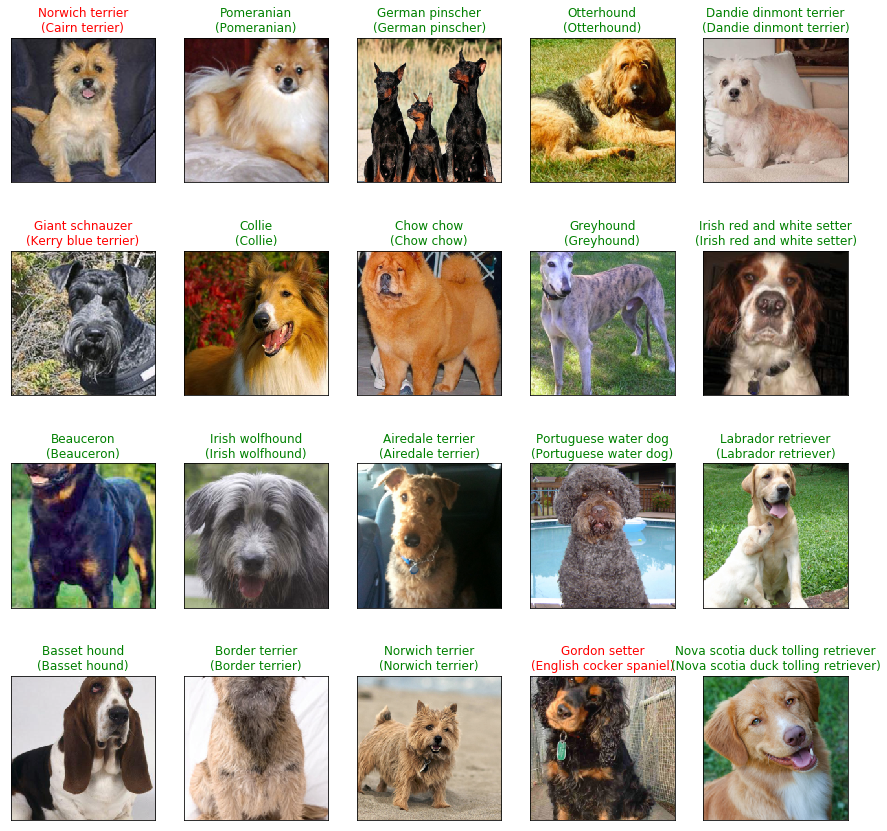

```python
# Helper function to un-normalize and display an image
def imshow(img):
    img = img.cpu()
    img = img.numpy().transpose((1, 2, 0))
    mean = np.array([0.485, 0.456, 0.406])
    stdev = np.array([0.229, 0.224, 0.225])
    img = stdev * img + mean
    img = np.clip(img, 0, 1)
    plt.imshow(img)

# Obtain one batch of training images
dataiter = iter(loaders_transfer['test'])
images, labels = dataiter.next()

if use_cuda: images = images.cuda()

model_transfer.eval()
output = model_transfer(images)
_, preds_tensor = torch.max(output, 1)
preds = np.squeeze(preds_tensor.numpy()) if not use_cuda else np.squeeze(preds_tensor.cpu().numpy())

# Plot the images in the batch, along with the corresponding labels
fig = plt.figure(figsize = (15, 15))

# Display 20 images
for idx in np.arange(20):
    ax = fig.add_subplot(4, 20/4, idx + 1, xticks = [], yticks = [])
    imshow(images[idx])
    ax.set_title('{}\n({})'.format(class_names[preds[idx]], class_names[labels[idx]]),
                 color = ('green' if preds[idx] == labels[idx].item() else 'red'))
```

## Build Algorithm

Write an algorithm that accepts a file path to an image and first determines whether the image contains a human, dog, or neither. Then,

- if a **dog** is detected in the image, return the predicted breed.
- if a **human** is detected in the image, return the resembling dog breed.
- if **neither** is detected in the image, provide output that indicates an error.

You are welcome to write your own functions for detecting humans and dogs in images, but feel free to use the `face_detector` and `dog_detector` functions developed above. You are **required** to use your CNN from Step 4 to predict dog breed.

### (IMPLEMENTATION) Build Algorithm

```python
# Recall time...
def dog_detector(img_path):
    preds = VGG16_predict(img_path)
    return True if 151 <= preds <= 268 else False

def face_detector(img_path):
    img = cv2.imread(img_path)
    face_cascade = cv2.CascadeClassifier(cv2.data.haarcascades + 'haarcascade_frontalface_default.xml')
    gray = cv2.cvtColor(img, cv2.COLOR_BGR2GRAY)
    faces = face_cascade.detectMultiScale(gray)
    return len(faces) > 0

def display(img_path):
    img = Image.open(img_path)
    plt.imshow(img)
    plt.show()

# Building app
def run_app(img_path):
    # Handle cases for a human face, dog, and neither
    if dog_detector(img_path):
        print('Hello Dog!')
        display(img_path)
        print('Predicted breed for you... {}'.format(class_names[predict_breed_transfer(img_path)]))
    elif face_detector(img_path):
        print('Hello Human!')
        display(img_path)
        print('You look like a... {}'.format(class_names[predict_breed_transfer(img_path)]))
    else:
        print('You\'re niether a Human nor a Dog!!')
        display(img_path)
    return
```

## Test Algorithm

In this section, you will take your new algorithm for a spin! What kind of dog does the algorithm think that *you* look like? If you have a dog, does it predict your dog's breed accurately? If you have a cat, does it mistakenly think that your cat is a dog?

### (IMPLEMENTATION) Test Algorithm on Sample Images!

Test your algorithm at least six images on your computer. Feel free to use any images you like. Use at least two human and two dog images.

**Question 6:** Is the output better than you expected :) ? Or worse :( ? Provide at least three possible points of improvement for your algorithm.

**Answer:** Output is as I expected. Three possible improvements could have been:

- Exploring different transfer learning algorithms.
- Data augmentation techniques.
- Different lr scheduler that provides several methods to adjust the learning rate based on the number of epochs.
- Fine tuning SGD optimizer using momentum.

```
Hello Human!
```

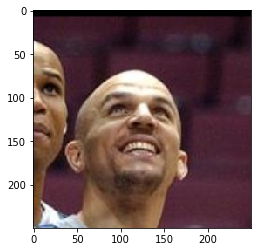

```
You look like a... American staffordshire terrier


Hello Human!
```

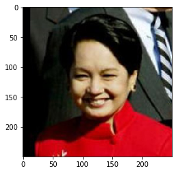

```
You look like a... Finnish spitz


Hello Human!
```

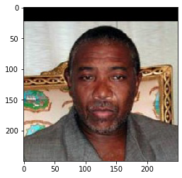

```
You look like a... Dachshund


Hello Dog!
```

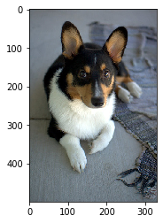

```
Predicted breed for you... Pembroke welsh corgi


Hello Dog!
```

[figure not shown]

```
Predicted breed for you... Cairn terrier


Hello Dog!
```

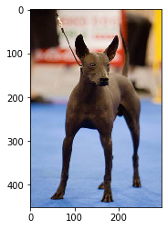

```
Predicted breed for you... Manchester terrier
```

```python
## Execute your algorithm from Step 6 on at least 6 images on your computer
for file in np.hstack((human_files[[random.randint(1, 13233),
                                   random.randint(1, 13233),
                                   random.randint(1, 13233)]],
                       dog_files[[random.randint(1, 836),
                                 random.randint(1, 836),
                                 random.randint(1, 836)]])):
    run_app(file); print('\n')
```

```
Hello Human!
```

[figure not shown]

```
You look like a... Beauceron


Hello Human!
```

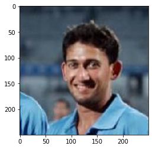

```
You look like a... Beauceron


Hello Human!
```

[figure not shown]

```
You look like a... Dachshund


Hello Dog!
```

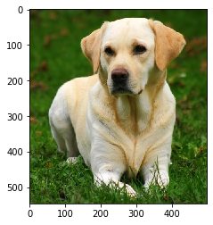

```
Predicted breed for you... Labrador retriever


Hello Human!
```

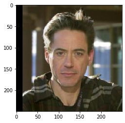

```
You look like a... American staffordshire terrier


Hello Dog!
```

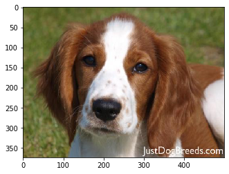

```
Predicted breed for you... Irish red and white setter
```

```python
for images in np.array(glob('sampleImages/*')):
    run_app(images);
    print('\n')
```